# Курсовая работа. Блок 1

### 3.1, 3.2 Рассчёт статистических характеристик времени прохождения каждого модуля и построение графиков

```python
les_p_mod['Минимум'] = None
les_p_mod['Максимум'] = None
les_p_mod['Среднее'] = None
les_p_mod['Медиана'] = None
les_p_mod['standart_deviation_p'] = None #Будет использоваться в метрике успеваемости
les_p_mod['standart_deviation_n'] = None
les_p_mod['start_token'] = None
les_p_mod['finish_token'] = None
les_p_mod.reset_index(inplace = True)
les_p_mod.head()
```

|  | Название курса | Название модуля | Количество уроков | Минимум | Максимум | Среднее | Медиана | standart_deviation_p | standart_deviation_n | start_token | finish_token |
| --- | --- | --- | --- | --- | --- | --- | --- | --- | --- | --- | --- |
| 0 | Java-разработчик c нуля | Вводный модуль | 7 | None | None | None | None | None | None | None | None |
| 1 | Java-разработчик c нуля | Синтаксис языка | 6 | None | None | None | None | None | None | None | None |
| 2 | Java-разработчик c нуля | Объекты и классы | 10 | None | None | None | None | None | None | None | None |
| 3 | Java-разработчик c нуля | Числа, строки и даты | 27 | None | None | None | None | None | None | None | None |
| 4 | Java-разработчик c нуля | Массивы и коллекции | 13 | None | None | None | None | None | None | None | None |

```python
from math import sqrt
def std(args):
    mean = np.mean(args)
    args1 = list(args >= mean)
    args2 = list(args < mean)
    stdp = sqrt(sum(list(map(lambda x: (x - mean)**2, args1)))/(len(args1) - 1))
    stdn = sqrt(sum(list(map(lambda x: (x - mean)**2, args2)))/(len(args2) - 1))
    return [stdp, stdn]
```

```python
sorted(list(set(courses[(courses.title == 'Анимация интерфейсов') & (courses.is_homework == True)].module_number)))
```

```
[1, 2, 3, 4, 5, 7, 8, 10, 11, 12, 13, 14, 15, 18, 21]
```

```
Модули, выполнение которых еще не завершено:

Анимация интерфейсов:InVision Studio
```

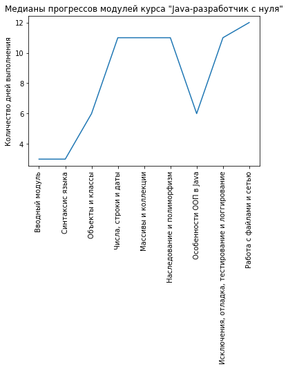

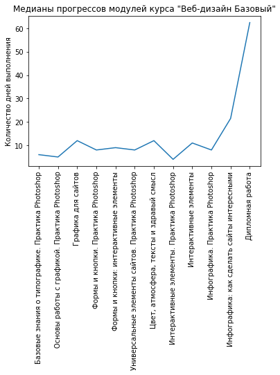

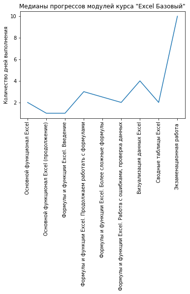

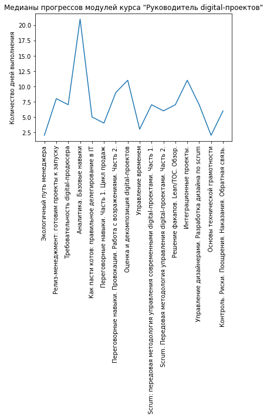

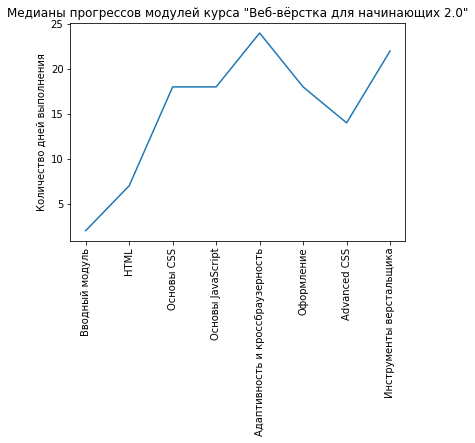

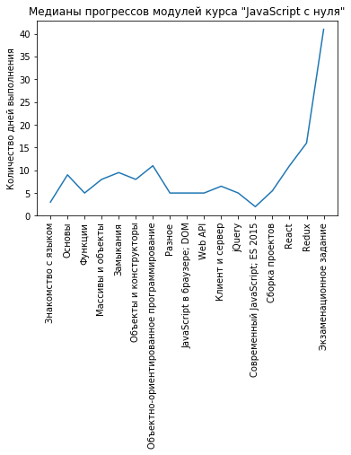

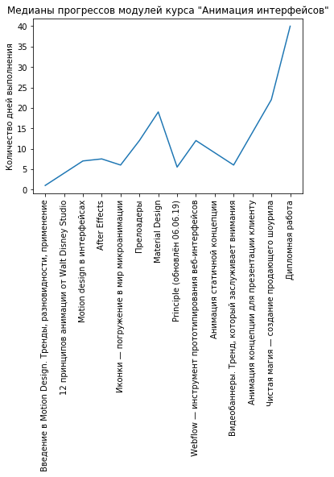

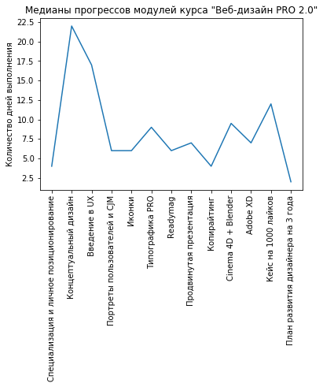

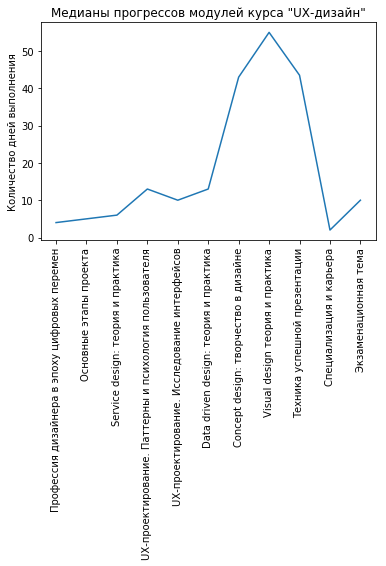

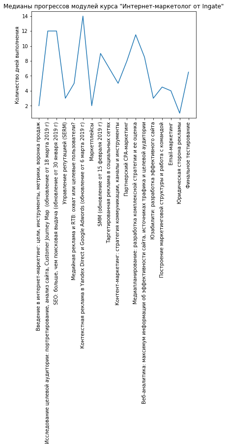

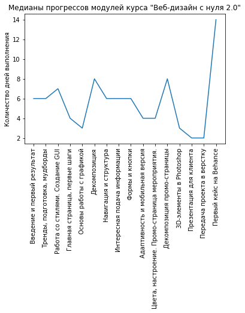

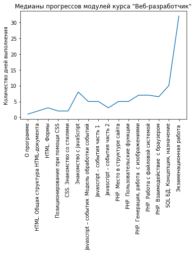

[3 more figures not shown]

```python
import numpy as np
from datetime import datetime
directory = 'CreatedData3/'
to_date = lambda s: datetime.strptime(s[:19], "%Y-%m-%d %H:%M:%S")
day = lambda date: int(int(str(date).split()[0])/(24*3600*(10**9)))
i = 0
print('Модули, выполнение которых еще не завершено:\n')
for course in id_title.values():
    for module in list(les_p_mod[les_p_mod['Название курса'] == course]['Название модуля']):
        hws = list(courses[(courses.module_title == module) &
                           (courses.title == course) &
                           (courses.is_homework == True)].lesson_token)
        if len(hws) == 1:
            hwdf = main[(main.lesson_token == hws[0]) &
                        (main.status == 'done')]
            start_date = (hwdf.start_date).apply(to_date)
            finish_date = (hwdf.finish_date).apply(to_date)
            les_p_mod.iloc[i, 9], les_p_mod.iloc[i, 10] = hws[0], hws[0]
            delta = list(map(day,(list(np.array(finish_date) - np.array(start_date)))))
            delta = np.array(delta)
            delta = delta[delta >= 0]
            try:
                les_p_mod.iloc[i, 3] = min(delta)
                les_p_mod.iloc[i, 4] = max(delta)
                les_p_mod.iloc[i, 5] = np.mean(delta)
                les_p_mod.iloc[i, 6] = np.median(delta)
                les_p_mod.iloc[i, 7], les_p_mod.iloc[i, 8] = std(delta)
            except:
                print(course, module, sep = ':')
        elif len(hws) > 1:
            hwdff = main[(main.lesson_token == hws[-1]) &
                        (main.status == 'done')]
            hwdfs = main[(main.lesson_token == hws[0]) &
                        (main.status == 'done')]
            stud_del = list(set(hwdfs.student_id) - (set(hwdfs.student_id) & set(hwdff.student_id)))
            for j in stud_del:
                hwdfs = hwdfs[hwdfs.student_id != j]
            stud_del = list(set(hwdff.student_id) - (set(hwdfs.student_id) & set(hwdff.student_id)))
            for j in stud_del:
                hwdff = hwdff[hwdff.student_id != j]
            hwdfs.sort_values(by = ['student_id'])
            hwdff.sort_values(by = ['student_id'])
            start_date = (hwdfs.start_date).apply(to_date)
            finish_date = (hwdff.finish_date).apply(to_date)
            les_p_mod.iloc[i, 9], les_p_mod.iloc[i, 10] = hws[0], hws[-1]
            delta = list(map(day,(list(np.array(finish_date) - np.array(start_date)))))
            delta = np.array(delta)
            delta = delta[delta >= 0]
            try:
                les_p_mod.iloc[i, 3] = min(delta)
                les_p_mod.iloc[i, 4] = max(delta)
                les_p_mod.iloc[i, 5] = np.mean(delta)
                les_p_mod.iloc[i, 6] = np.median(delta)
                les_p_mod.iloc[i, 7], les_p_mod.iloc[i, 8] = std(delta)
            except:
                print(course, module, sep = ':')
        i += 1
    filename = f'MedianModule_{course}.png'
    fig, subplot = plt.subplots()
    cur_df = les_p_mod[les_p_mod['Название курса'] == course].dropna()
    mod_nums = int(mod_p_course[mod_p_course['Название курса'] == course]['Количество модулей'])
    subplot.plot(list(map(str, list(cur_df['Название модуля']))),
                  cur_df['Медиана'])
    subplot.set_ylabel('Количество дней выполнения')
    subplot.set_title(f'Медианы прогрессов модулей курса "{course}"')
    plt.xticks(cur_df['Название модуля'], rotation = 'vertical')
    plt.savefig(directory + filename, bbox_inches = 'tight')
```

```python
les_p_mod.dropna(inplace = True)
```

```python
course_legend = pd.DataFrame({'Курс':list(courses.title),
                        'Номер модуля':list(courses.module_number),
                        'Модуль':list(courses.module_title)})
course_legend.drop_duplicates(inplace = True)
```

```python
course_legend.reset_index(inplace = True)
del course_legend['index']
course_legend.head(10)
```

|  | Курс | Номер модуля | Модуль |
| --- | --- | --- | --- |
| 0 | Java-разработчик c нуля | 1 | Вводный модуль |
| 1 | Java-разработчик c нуля | 2 | Синтаксис языка |
| 2 | Java-разработчик c нуля | 3 | Объекты и классы |
| 3 | Java-разработчик c нуля | 4 | Числа, строки и даты |
| 4 | Java-разработчик c нуля | 5 | Массивы и коллекции |
| 5 | Java-разработчик c нуля | 6 | Наследование и полиморфизм |
| 6 | Java-разработчик c нуля | 7 | Особенности ООП в Java |
| 7 | Java-разработчик c нуля | 8 | Исключения, отладка, тестирование и логгирование |
| 8 | Java-разработчик c нуля | 9 | Работа с файлами и сетью |
| 9 | Веб-дизайн Базовый | 1 | Интерфейс. Практика Photoshop |

```python
course_legend[course_legend['Курс'] == 'Веб-разработчик']
```

|  | Курс | Номер модуля | Модуль |
| --- | --- | --- | --- |
| 173 | Веб-разработчик | 1 | О программе |
| 174 | Веб-разработчик | 2 | HTML. Общая структура HTML-документа |
| 175 | Веб-разработчик | 3 | HTML. Формы |
| 176 | Веб-разработчик | 4 | Позиционирование при помощи CSS |
| 177 | Веб-разработчик | 5 | CSS. Знакомство со стилями |
| 178 | Веб-разработчик | 6 | Знакомство с JavaScript |
| 179 | Веб-разработчик | 7 | Javascript – события. Модель обработки событий |
| 180 | Веб-разработчик | 8 | Javascript – события часть 1 |
| 181 | Веб-разработчик | 9 | Javascript – события часть 2 |
| 182 | Веб-разработчик | 10 | PHP. Место в структуре сайта |
| 183 | Веб-разработчик | 11 | PHP. Пользовательские функции |
| 184 | Веб-разработчик | 12 | PHP. Генерация, работа с изображениями |
| 185 | Веб-разработчик | 13 | PHP. Работа с файловой системой |
| 186 | Веб-разработчик | 14 | PHP. Взаимодействие с браузером |
| 187 | Веб-разработчик | 15 | SQL БД. Концепция, назначение |
| 188 | Веб-разработчик | 16 | Замена текстового файла на Postgresql в качест... |
| 189 | Веб-разработчик | 17 | Материалы для экзамена |
| 190 | Веб-разработчик | 18 | Экзаменационная работа |
| 191 | Веб-разработчик | 19 | Дополнительные модули |
| 192 | Веб-разработчик | 20 | Проверка |

### 3.3, 3.4 Рассчёт сезонности выполнения домашних заданий и построение графика

```python
from copy import deepcopy

just_month = lambda x: x[5:7]
season_progress = deepcopy(month_growth[(month_growth['Месяцы'] > '2018') & (month_growth['Месяцы'] < '2019')])
season_progress['Месяцы'] = season_progress['Месяцы'].apply(just_month)
season_progress.set_index(['Месяцы'], inplace = True)
main['month'] = main.start_date.apply(just_month)
```

[output not shown]

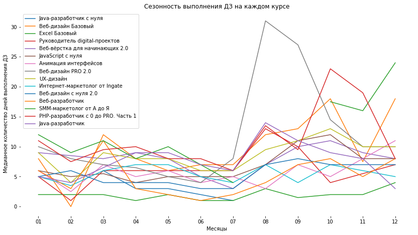

```python
# для перевода в тип datetime
to_date = lambda s: datetime.strptime(s[:19], "%Y-%m-%d %H:%M:%S")

# для подсчёта дней из типа данных numpy.datetime
day = lambda date: int(int(str(date).split()[0])/(24*3600*(10**9)))

fig, subplot = plt.subplots()
fig.set_size_inches(14, 7.5)
main_done = main[(main.status == 'done') & (main.is_homework == True)]
for course in id_title.values():
    course_df = main_done[(main_done.title == course)]
    for month in list(season_progress.index):
        month_df = course_df[course_df.month == month]
        if len(month_df) != 0:
            st_arr = np.array(month_df.start_date.apply(to_date))
            fin_arr = np.array(month_df.finish_date.apply(to_date))
            delta = list(map(day,(list(np.array(fin_arr) - np.array(st_arr)))))
            med = np.median(list(map(day,(list(np.array(fin_arr) - np.array(st_arr))))))
            season_progress.loc[month, course] = med
        else:
            season_progress.loc[month, course] = None
    subplot.plot(season_progress.index, season_progress[course])
subplot.spines['top'].set_visible(False)
subplot.spines['right'].set_visible(False)
subplot.spines['bottom'].set_visible(False)
subplot.spines['left'].set_visible(False)
subplot.set_ylabel('Медианное количество дней выполнения ДЗ')
subplot.set_xlabel('Месяцы')
subplot.set_title('Сезонность выполнения ДЗ на каждом курсе')
subplot.legend(loc = 'upper left')
plt.savefig('CreatedData3/SeasonHW.png', bbox_inches = 'tight')
season_progress
```

```python
season_progress
```

| Месяцы | Java-разработчик c нуля | Веб-дизайн Базовый | Excel Базовый | Руководитель digital-проектов | Веб-вёрстка для начинающих 2.0 | JavaScript с нуля | Анимация интерфейсов | Веб-дизайн PRO 2.0 | UX-дизайн | Интернет-маркетолог от Ingate | Веб-дизайн с нуля 2.0 | Веб-разработчик | SMM-маркетолог от А до Я | PHP-разработчик с 0 до PRO. Часть 1 | Java-разработчик |
| --- | --- | --- | --- | --- | --- | --- | --- | --- | --- | --- | --- | --- | --- | --- | --- |
| 01 | NaN | 8.0 | 2.0 | 5.0 | 9.0 | 6.0 | 6.0 | 10.0 | 9.0 | 5.0 | 5.0 | 6.0 | 12.0 | 11.0 | 5.0 |
| 02 | NaN | 0.0 | 2.0 | 1.0 | 8.5 | 5.0 | 2.5 | 8.0 | 4.0 | 3.5 | 6.0 | 3.0 | 9.0 | 7.5 | 4.0 |
| 03 | 6.0 | 12.0 | 2.0 | 6.0 | 8.0 | 5.5 | 7.0 | 7.0 | 9.0 | 6.0 | 4.0 | 11.0 | 11.0 | 9.5 | 6.5 |
| 04 | 3.0 | 8.0 | 1.0 | 6.0 | 9.0 | 4.0 | 5.0 | 6.5 | 8.0 | 7.0 | 4.0 | 3.0 | 8.0 | 10.0 | 9.0 |
| 05 | 3.0 | 6.0 | 2.0 | 6.0 | 8.0 | 5.0 | 6.0 | 5.0 | 8.0 | 7.0 | 4.0 | 2.0 | 10.0 | 8.0 | 9.0 |
| 06 | 2.0 | 7.0 | 1.0 | 6.0 | 5.0 | 5.0 | 4.0 | 4.0 | 6.0 | 5.0 | 3.0 | 1.0 | 7.0 | 8.0 | 7.0 |
| 07 | 1.0 | 7.0 | 1.0 | 6.0 | 3.0 | 5.0 | 5.0 | 8.0 | 6.0 | 4.0 | 3.0 | 2.0 | 4.0 | 6.0 | 6.0 |
| 08 | NaN | 12.0 | 3.0 | 13.0 | 7.0 | 7.0 | 3.0 | 31.0 | 9.5 | 7.0 | 7.0 | 4.0 | NaN | 13.5 | 14.0 |
| 09 | NaN | 13.0 | 1.5 | 10.0 | 10.0 | 11.0 | 7.0 | 27.0 | 11.0 | 4.0 | 8.0 | 7.0 | NaN | 9.5 | 11.0 |
| 10 | NaN | 18.0 | 2.0 | 4.0 | 11.0 | 12.0 | 5.0 | 14.5 | 13.0 | 7.0 | 7.0 | 8.0 | 17.5 | 23.0 | 9.0 |
| 11 | NaN | 7.5 | 2.0 | 5.5 | 9.0 | 8.0 | 8.0 | 10.0 | 10.0 | 6.0 | 7.0 | 5.0 | 16.0 | 19.0 | 8.0 |
| 12 | NaN | 18.0 | 4.0 | 7.0 | 8.0 | 8.0 | 11.0 | 10.0 | 10.0 | 5.0 | 7.0 | 8.0 | 24.0 | 8.0 | 3.0 |

### 3.5 Аналитический вывод

[figure not shown]

1. *Выполнение домашней работы по модулям*

   В данных графиках трудно найти похожие, хотя некоторые из них приблизительно обладают схожими чертами. Например, курсы, связанные с разработкой, обладают свойством модулей *от простого к сложному* (PHP, Java-разработчик с нуля), где время выполнения ДЗ увеличивается по мере продвижения по модулям. В основном же встречаются курсы с равномерным распределением нагрузки: либо время выполнения находится примерно на одном уровне для каждого модуля, либо пики и спады чередуются таким образом, что слишеом простые модули компенсируют слишком сложные. Часто наблдается аномальное возрастание - оно присутствует в связи с наступлением курсовых, дипломных или экзаменационных работ.

   Дольше всего выполняются модули, связанные с дизайном или вебом. Проще всего студентам даются курсы по маркетологии/бизнесу. Сложность курсов по разработке на среднем уровне.

   *На курсе *Анимация интерфесов* присутствует разрыв. Скорее всего, модуль под номером 12 был добавлен позже (в виде обновления), чем студенты завершили прохождение курса.

[figure not shown]

1. *Сезонность выполнения дз*

## 4. Расчет конверсии

1. **(p)** Посчитать конверсию перехода студентов из одного модуля в другой на каждом курсе. Формула: отношение количества студентов, приступивших к выполнению домашнего задания в этом модуле (если дз в модуле несколько, то считать по первому дз в модуле), к количеству студентов, сдавших задание в предыдущем модуле (если дз в модуле несколько, то считать по последнему дз в модуле).
2. **(m)** Постройте bar-chart, отражающий конверсию перехода студентов из одного модуля в другой на каждом курсе. График должен иметь заголовок. Ticks нужно развернуть так, чтобы они были читаемы
3. **(m)** Постройте горизонтальный (столбцы должны располагаться горизонтально) bar-chart, отражающий конверсию перехода студентов из одного модуля в другой на каждом курсе. 15 графиков. Графики должны иметь заголовки. Ticks должны содержать номер и название модуля. Цвет столбцов графиков должен содержать информацию о сфере, к которой относится курс (нужна легенда). Прозрачность должна стоять на отметке 0.1. На графики должна быть нанесена линия медианы конверсии для каждого курса. У медианы должен быть свой цвет. Рамок у графиков быть не должно ⭐
4. На основании рассчитанных значений сделайте аналитический вывод (должен быть полным и покрывать все полученные выше метрики)

### 4.1 Рассчёт помодульной конверсии

```python
conversion_frame = pd.DataFrame(columns = ('course', 'module_finish', 'module_start', 'conversion', 'f_s'))
for course in id_title.values():
    started, finished = 0, 0
    cur_df = main[(main.title == course) & (main.is_homework == True)]
    #Отбрасываем модули, в которых нет уроков с ДЗ
    modules_wh =  list(courses[(courses.title == course) &
                               (courses.is_homework == True)].module_number.drop_duplicates())
    if course == 'Анимация интерфейсов':
        modules_wh.remove(12) #Удаляем 12-ый модуль, поскольку там к дз никто не приступал
    for module in range(len(modules_wh) - 1):
        hw1 = list(courses[(courses.title == course) &
                           (courses.module_number == modules_wh[module]) &
                           (courses.is_homework == True)].lesson_token)[-1]
        hw2 = list(courses[(courses.title == course) &
                           (courses.module_number == modules_wh[module + 1]) &
                           (courses.is_homework == True)].lesson_token)[0]

        len1 = len(cur_df[(cur_df.status == 'done') & (cur_df.lesson_token == hw1)]) # Завершившие предыдущий модуль
        len2 = len(cur_df[cur_df.lesson_token == hw2]) # Приступившие к следующему модулю
        conversion_frame.loc[len(conversion_frame)] = (course,
                                                        modules_wh[module],
                                                        modules_wh[module + 1],
                                                        len2/len1 if len1!=0 else None,
                                                        f'{modules_wh[module]}-{modules_wh[module + 1]}')
```

```python
conversion_frame
```

|  | course | module_finish | module_start | conversion | f_s |
| --- | --- | --- | --- | --- | --- |
| 0 | Java-разработчик c нуля | 1 | 2 | 0.985866 | 1-2 |
| 1 | Java-разработчик c нуля | 2 | 3 | 0.954751 | 2-3 |
| 2 | Java-разработчик c нуля | 3 | 4 | 1.080000 | 3-4 |
| 3 | Java-разработчик c нуля | 4 | 5 | 0.963636 | 4-5 |
| 4 | Java-разработчик c нуля | 5 | 6 | 0.986667 | 5-6 |
| 5 | Java-разработчик c нуля | 6 | 7 | 1.083333 | 6-7 |
| 6 | Java-разработчик c нуля | 7 | 8 | 0.891892 | 7-8 |
| 7 | Java-разработчик c нуля | 8 | 9 | 1.000000 | 8-9 |
| 8 | Веб-дизайн Базовый | 3 | 5 | 0.954802 | 3-5 |
| 9 | Веб-дизайн Базовый | 5 | 6 | 0.990741 | 5-6 |
| 10 | Веб-дизайн Базовый | 6 | 7 | 0.985612 | 6-7 |
| 11 | Веб-дизайн Базовый | 7 | 8 | 1.000000 | 7-8 |
| 12 | Веб-дизайн Базовый | 8 | 9 | 0.991379 | 8-9 |
| 13 | Веб-дизайн Базовый | 9 | 10 | 1.004717 | 9-10 |
| 14 | Веб-дизайн Базовый | 10 | 11 | 1.011050 | 10-11 |
| 15 | Веб-дизайн Базовый | 11 | 12 | 1.017442 | 11-12 |
| 16 | Веб-дизайн Базовый | 12 | 13 | 1.012903 | 12-13 |
| 17 | Веб-дизайн Базовый | 13 | 14 | 1.026846 | 13-14 |
| 18 | Веб-дизайн Базовый | 14 | 17 | 1.098361 | 14-17 |
| 19 | Excel Базовый | 1 | 2 | 0.947598 | 1-2 |
| 20 | Excel Базовый | 2 | 3 | 0.980296 | 2-3 |
| 21 | Excel Базовый | 3 | 4 | 0.891473 | 3-4 |
| 22 | Excel Базовый | 4 | 5 | 0.983498 | 4-5 |
| 23 | Excel Базовый | 5 | 6 | 0.974074 | 5-6 |
| 24 | Excel Базовый | 6 | 7 | 0.983471 | 6-7 |
| 25 | Excel Базовый | 7 | 8 | 1.010000 | 7-8 |
| 26 | Excel Базовый | 8 | 9 | 1.026882 | 8-9 |
| 27 | Руководитель digital-проектов | 1 | 2 | 0.958929 | 1-2 |
| 28 | Руководитель digital-проектов | 2 | 3 | 1.072000 | 2-3 |
| 29 | Руководитель digital-проектов | 3 | 4 | 0.971014 | 3-4 |
| ... | ... | ... | ... | ... | ... |
| 145 | Веб-разработчик | 14 | 15 | 1.152174 | 14-15 |
| 146 | Веб-разработчик | 15 | 18 | 1.303030 | 15-18 |
| 147 | SMM-маркетолог от А до Я | 1 | 2 | 0.818182 | 1-2 |
| 148 | SMM-маркетолог от А до Я | 2 | 3 | 0.948276 | 2-3 |
| 149 | SMM-маркетолог от А до Я | 3 | 4 | 0.564356 | 3-4 |
| 150 | SMM-маркетолог от А до Я | 4 | 5 | 1.217391 | 4-5 |
| 151 | SMM-маркетолог от А до Я | 5 | 6 | 5.055556 | 5-6 |
| 152 | SMM-маркетолог от А до Я | 6 | 8 | 0.969231 | 6-8 |
| 153 | PHP-разработчик с 0 до PRO. Часть 1 | 1 | 2 | 0.855305 | 1-2 |
| 154 | PHP-разработчик с 0 до PRO. Часть 1 | 2 | 3 | 1.307692 | 2-3 |
| 155 | PHP-разработчик с 0 до PRO. Часть 1 | 3 | 4 | 1.024000 | 3-4 |
| 156 | PHP-разработчик с 0 до PRO. Часть 1 | 4 | 5 | 1.137500 | 4-5 |
| 157 | PHP-разработчик с 0 до PRO. Часть 1 | 5 | 6 | 1.055556 | 5-6 |
| 158 | PHP-разработчик с 0 до PRO. Часть 1 | 6 | 7 | 0.981818 | 6-7 |
| 159 | PHP-разработчик с 0 до PRO. Часть 1 | 7 | 8 | 1.194444 | 7-8 |
| 160 | Java-разработчик | 1 | 2 | 0.925400 | 1-2 |
| 161 | Java-разработчик | 2 | 3 | 0.875878 | 2-3 |
| 162 | Java-разработчик | 3 | 4 | 0.962585 | 3-4 |
| 163 | Java-разработчик | 4 | 5 | 0.931034 | 4-5 |
| 164 | Java-разработчик | 5 | 6 | 1.011561 | 5-6 |
| 165 | Java-разработчик | 6 | 7 | 0.987500 | 6-7 |
| 166 | Java-разработчик | 7 | 8 | 0.957746 | 7-8 |
| 167 | Java-разработчик | 8 | 9 | 1.056604 | 8-9 |
| 168 | Java-разработчик | 9 | 10 | 1.013514 | 9-10 |
| 169 | Java-разработчик | 10 | 11 | 1.045455 | 10-11 |
| 170 | Java-разработчик | 11 | 12 | 1.019608 | 11-12 |
| 171 | Java-разработчик | 12 | 13 | 1.064516 | 12-13 |
| 172 | Java-разработчик | 13 | 14 | 0.961538 | 13-14 |
| 173 | Java-разработчик | 14 | 15 | 1.043478 | 14-15 |
| 174 | Java-разработчик | 15 | 17 | 1.105263 | 15-17 |

175 rows × 5 columns

### 4.2 Графики конверсий (вертикальные бар-чарты)

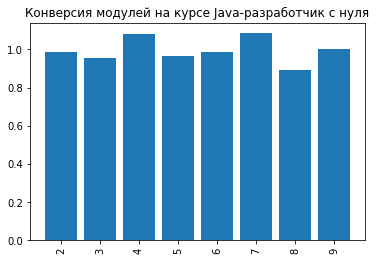

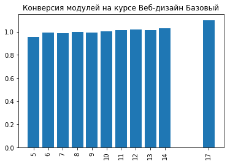

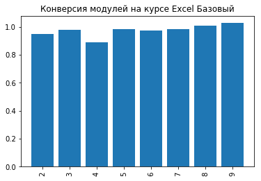

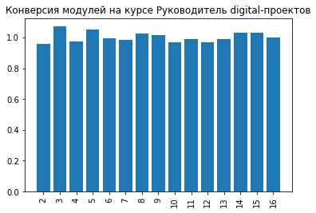

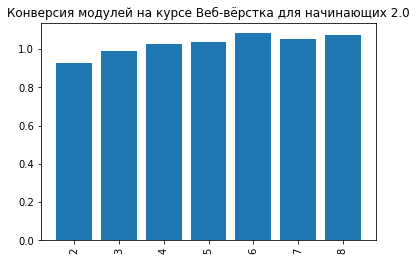

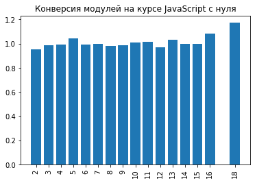

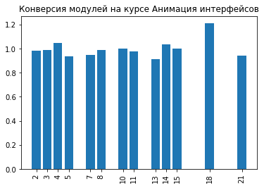

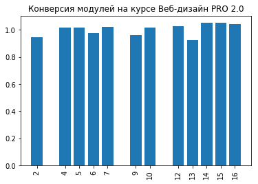

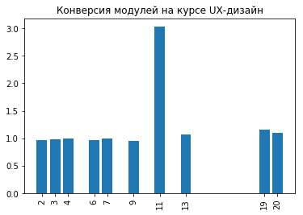

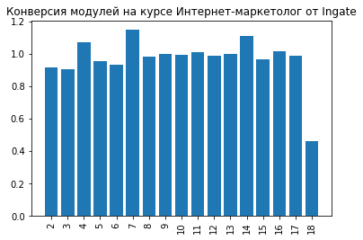

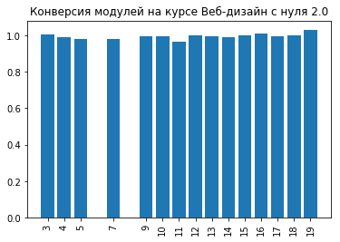

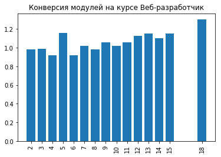

[3 more figures not shown]

```python
from matplotlib import pyplot as plt
for course in id_title.values():
    rmc()
    fig, subplot = plt.subplots()
    cur_frame = conversion_frame[conversion_frame.course == course]
    subplot.bar(cur_frame.module_start, cur_frame.conversion)
    subplot.set_title(f'Конверсия модулей на курсе {course}')
    plt.xticks(ticks = cur_frame.module_start, labels = cur_frame.module_start.apply(str), rotation = 'vertical')
    plt.savefig(f"CreatedData4/ConversionBar_{course}.png", bbox_inches = 'tight')
# разрывы - это модули, в которых нет дз
```

### 4.3 Отформатированные графики конверсий (горизонтальные бар-чарты)

```python
# список из имён модулей
conversion_modname = {i:list() for i in id_title.values()}
for course, mod in (tuple(zip(list(conversion_frame.course),
                    list(conversion_frame.module_start)))):
    conversion_modname[course].append(str(course_legend[(course_legend['Курс'] == course) &
                      (course_legend['Номер модуля'] == mod)].reset_index()['Модуль'][0]) + f'({mod})')
```

```python
conversion_modname
```

```
{'Java-разработчик c нуля': ['Синтаксис языка(2)',
  'Объекты и классы(3)',
  'Числа, строки и даты(4)',
  'Массивы и коллекции(5)',
  'Наследование и полиморфизм(6)',
  'Особенности ООП в Java(7)',
  'Исключения, отладка, тестирование и логгирование(8)',
  'Работа с файлами и сетью(9)'],
 'Веб-дизайн Базовый': ['Основы работы с графикой. Практика Photoshop(5)',
  'Графика для сайтов(6)',
  'Формы и кнопки. Практика Photoshop(7)',
  'Формы и кнопки: интерактивные элементы(8)',
  'Универсальные элементы сайтов. Практика Photoshop(9)',
  'Цвет, атмосфера, тексты и здравый смысл(10)',
  'Интерактивные элементы. Практика Photoshop(11)',
  'Интерактивные элементы(12)',
  'Инфографика. Практика Photoshop(13)',
  'Инфографика: как сделать сайты интересными(14)',
  'Дипломная работа(17)'],
 'Excel Базовый': ['Основной функционал Excel (продолжение)(2)',
  'Формулы и функции Excel. Введение(3)',
  'Формулы и функции Excel. Продолжаем работать с формулами(4)',
  'Формулы и функции Excel. Более сложные формулы(5)',
  'Формулы и функции Excel. Работа с ошибками, проверка данных(6)',
  ' Визуализация данных Excel(7)',
  'Сводные таблицы Excel(8)',
  'Экзаменационная работа (9)'],
 'Руководитель digital-проектов': ['Релиз-менеджмент: готовим проекты к запуску(2)',
  'Требовательность digital-продюсера(3)',
  'Аналитика. Базовые навыки(4)',
  'Как пасти котов: правильное делегирование в IT(5)',
  'Переговорные навыки. Часть 1. Цикл продаж(6)',
  'Переговорные навыки. Провокации. Работа с возражениями. Часть 2.(7)',
  'Оценка и декомпозиция digital-проектов(8)',
  'Управление временем(9)',
  'Scrum: передовая методология управления современными digital-проектами. Часть 1.(10)',
  'Scrum. Передовая методология управления digital-проектами. Часть 2.(11)',
  'Решение факапов. Lean/TOC. Обзор.(12)',
  'Интеграционные проекты.(13)',
  'Управление дизайнерами. Разработка дизайна по scrum(14)',
```

[output cut: 120 more lines]

```
 'Java-разработчик': ['Синтаксис языка(2)',
  'Объекты и классы(3)',
  'Числа, строки и даты(4)',
  'Массивы и коллекции(5)',
  'Наследование и полиморфизм(6)',
  'Тестирование и отладка(7)',
  'Основы построения GUI(8)',
  'Внешний вид GUI и рисование(9)',
  'Работа с файлами и сетью(10)',
  'Работа с базами данных(11)',
  'Многопоточность(12)',
  'Оптимизация кода и приложений(13)',
  'Основы построения веб-приложений(14)',
  'Веб-приложения: формы, заголовки и сессии(15)',
  'Итоговая тема(17)']}
```

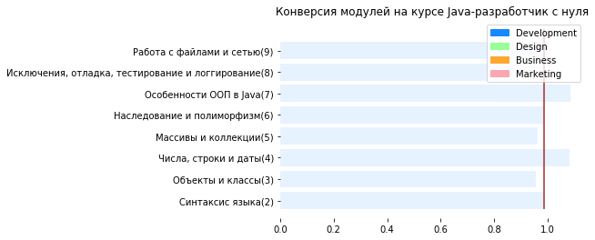

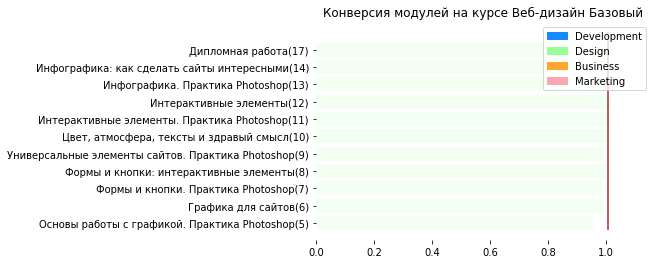

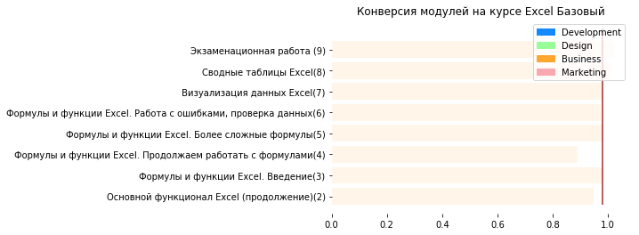

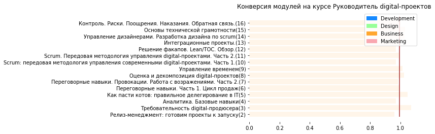

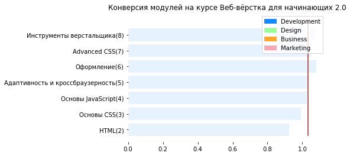

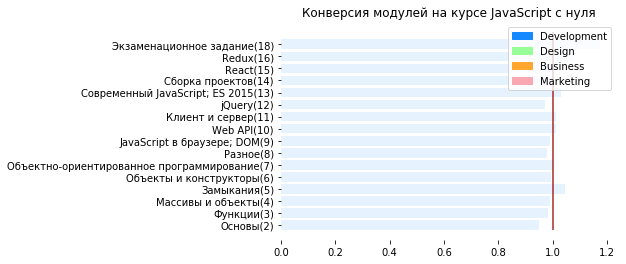

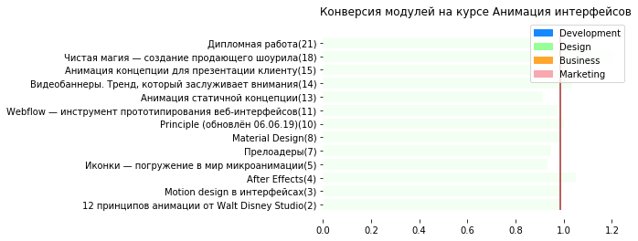

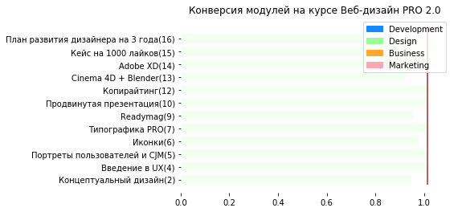

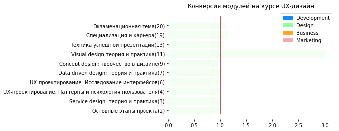

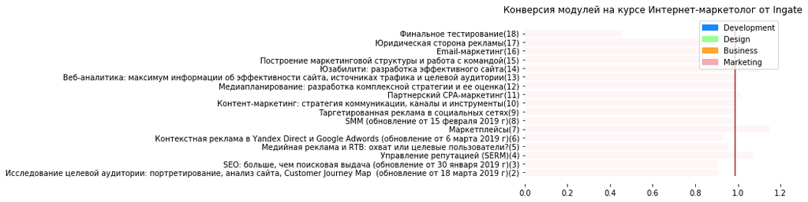

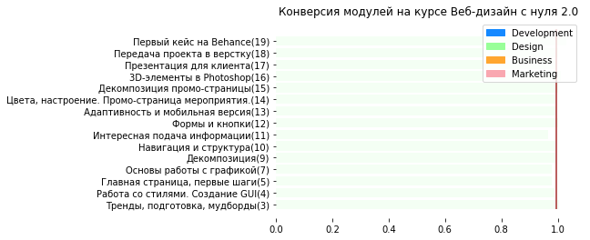

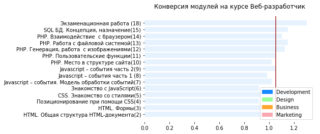

[3 more figures not shown]

```python
for course in id_title.values():
    fig, subplot = plt.subplots()
    subplot.barh(conversion_frame[conversion_frame.course == course].f_s,
                 conversion_frame[conversion_frame.course == course].conversion,
                 color = field_color[course_field[course]],
                 alpha = 0.1)
    subplot.set_title(f'Конверсия модулей на курсе {course}')
    subplot.legend(rect, tuple(field_color.keys()))
    med = np.median(conversion_frame[conversion_frame.course == course].conversion)
    subplot.vlines(med,-0.4,len(conversion_frame[conversion_frame.course == course]), color = 'brown')
    subplot.spines['top'].set_visible(False)
    subplot.spines['right'].set_visible(False)
    subplot.spines['bottom'].set_visible(False)
    subplot.spines['left'].set_visible(False)
    plt.yticks(range(len(conversion_modname[course])), labels = conversion_modname[course])
    plt.savefig(f"CreatedData4/ConversionBar_{course}_format.png", bbox_inches = 'tight')
```

[figure not shown]

## 5. Метрика успеваемости

*(необязательное задание)*

Иногда студенты берут курсы, которые оказываются для них неподъемными. Это может быть как по причинам недостаточной изначальной подготовки, так и по причинам, связанным с низкой мотивацией студента. Для улучшения качества контента полезно выявить причину. На основании имеющихся данных придумайте метрику успеваемости студента. **Обоснуйте ее.** Выявите таких студентов на каждом курсе, чтобы предоставить продюсерам список проблемных студентов.

### 5.1 Определение критериев успеваемости/неуспеваемости

Сделаем 4-хбалльную систему оценивания, похожую на общепринятую 5-ибалльную. На основе пункта *3.1* выявим степени успеваемости по времени выполнения модулей:

- 1 балл: от нормы стандартного отклонения до максимума

  (mean+stdp; max]

  неуд.
- 2 балла: от среднего значения до нормы стандартного отклонения

  \[mean; mean+stdp\]

  уд.
- 3 балла: от нормы стандартного отклонения

  [mean-stdn; mean)

  хор.
- 4 балла: от минимума до нормы стандартного отклонения

  [min; mean-stdn)

  отл.

Также в расчет будем брать студентов, выполнение заданий у которых не завершено на момент августа 2019 года и разница между началом выполнения модуля и этим месяцем больше допустимого максимума, или находится в диапазоне 1 балла.

#### Актуальность

Такая метрика хороша тем, что её объективность локальна. Т.е. мы не измеряем все модули по каким-то внешним стандартам и не устанавливаем единую шкалу оценивания, а определяем эти стандарты отдельно для каждого модуля каждого курса. Да, мы основывемся на общем принципе построения алгоритма, но при этом сохраняется "индивидуальный подход" к каждому курсу.

### 5.2 Реализация метрики

```python
# в пункте 3.1 я изменил алгоритм немного, чтобы датафрейм les_p_mod
# заполнился стандартными отклонениями в меньшую и большую сторону,
# также добавил start_token и finish_token для упрощения нахождения
# прохождения модулей.
```

```python
# создание списка действительных студентов
studset = list(set(main.student_id))
marks_df = pd.DataFrame(columns = ('student_id',
                                   'course',
                                   'mean',
                                   'status'))
august = "2019-08-01 00:00:00"
length = len(studset)
k = 0
first = datetime.now()
for student in studset:
    k += 1
    marks = []
    cur_df = main[(main.student_id == student) & (main.is_homework == True)]
    # убираем слишком мало выполнивших студентов
    if len(cur_df) == 1:
        continue

    # убираем тех, кто не выполнил ни одного дз
    if len(cur_df[cur_df.is_homework == True]) == 0:
        continue
    cur_df.reset_index(inplace = True)
    cur_course = set(cur_df.reset_index().title)
    maxi = 0
    course_ = None
    # находим курс-моду: курс, по которому студент прошел больше всего уроков
    for i in cur_course:
        l = len(cur_df[cur_df.title == i])
        if l > maxi:
            maxi = l
            course_ = i
    cur_course = course_
    last_lesson = les_p_mod[(les_p_mod['Название курса'] == cur_course)]
    last_lesson = last_lesson.reset_index().iloc[len(last_lesson) - 1]
    last_lesson = [last_lesson['Название модуля'], last_lesson['Количество уроков']]

    # отбираем студентов, не завершивших курс
    if len(cur_df[(cur_df.module_title == last_lesson[0]) &
              (cur_df.lesson_number == last_lesson[1]) &
              (cur_df.status == 'done')]) == 0:
        modules = sorted(list(set(cur_df[cur_df.title == cur_course].module_title)))
        for mod in modules:
            if mod == 'InVision Studio':
                continue
            cur_mod = les_p_mod[(les_p_mod['Название курса'] == cur_course) &
                              (les_p_mod['Название модуля'] == mod)]
            if len(cur_mod) == 0:
                continue
            cur_mod.reset_index(inplace = True)
            start = cur_mod.start_token[0]
            finish = cur_mod.finish_token[0]
            try:
                start = cur_df[cur_df.lesson_token == start].reset_index().start_date[0]
            except:
                continue
            if len(cur_df[cur_df.lesson_token == finish]) > 0:
                finish = cur_df[cur_df.lesson_token == finish].reset_index().finish_date[0]
            else:
                finish = august
            if str(finish) == 'nan':
                finish = august
            delta = to_date(finish) - to_date(start)
            days = delta.days
            # отбрасываем случаи, когда первое дз выполнялось позже последнего и выставляем оценку
            if days >= 0:
                mini = cur_mod['Минимум'][0]
                maxi = cur_mod['Максимум'][0]
                mean = cur_mod['Среднее'][0]
                stdp = cur_mod['standart_deviation_p'][0]
                stdn = cur_mod['standart_deviation_n'][0]
                mark = None
                if mini <= days < mean - stdn:
                    mark = 4
                elif mean - stdn <= days < mean:
                    mark = 3
                elif mean <= days <= mean + stdp:
                    mark = 2
                elif mean + stdp <= days <= maxi:
                    mark = 1
                else:
                    mark = 0
                marks.append(mark)

        # обходим, если по непонятным причинам оценок не выявлено
        if len(marks) == 0:
            continue
        # выставляем вердикт - степени успеваемости
        if (np.mean(marks) < 1):
            marks_df.loc[len(marks_df)] = (student,
                                          cur_course,
                                          np.mean(marks),
                                          'lags a lot')
        elif np.mean(marks) < 1.5:
            marks_df.loc[len(marks_df)] = (student,
                                          cur_course,
                                          np.mean(marks),
                                          'lags')
        elif np.mean(marks) < 2:
            marks_df.loc[len(marks_df)] = (student,
                                          cur_course,
                                          np.mean(marks),
                                          'lags a bit')
        if str(np.mean(marks)) == 'nan':
            break
marks_df.to_html('CreatedData5/AcademicPerformance.html')
```

Внизу представлен список неуспевающих студентов. Степень *неуспеваемости* ранжируется следующим образом:

- < 1: lags a lot - группа самых неуспевающих
- < 1.5: lags - группа отстающих
- < 2: lags a bit - группа студентов, отстающих периодически.

|  | student_id | course | mean | status |
| --- | --- | --- | --- | --- |
| 0 | f60f2b219c3eb3182862729bbb75a05e | UX-дизайн | 0.333333 | lags a lot |
| 1 | d38e9e540c2c300371a012dc9f5f0214 | Руководитель digital-проектов | 1.666667 | lags a bit |
| 2 | 72f774720584876a390848e99f4f18c3 | Интернет-маркетолог от Ingate | 1.500000 | lags a bit |
| 3 | 5827bb56b51b7a749be2ecaaa200d4d4 | PHP-разработчик с 0 до PRO. Часть 1 | 1.000000 | lags |
| 4 | acbd0baef1f2438797447e793adf2c0a | Веб-дизайн с нуля 2.0 | 1.000000 | lags |
| 5 | fe67b354fcd99aa081987b0ce5dbbb54 | Java-разработчик | 1.800000 | lags a bit |
| 6 | 35a6d7767998efde65b394e0b8b962c2 | Интернет-маркетолог от Ingate | 1.000000 | lags |
| 7 | 064f9cd14f7450887999ecc449665638 | Руководитель digital-проектов | 1.666667 | lags a bit |
| 8 | 5d5224c6ce7597cfb1f94f9d5ef42947 | Интернет-маркетолог от Ingate | 1.000000 | lags |
| 9 | 04ba196254f775ff03aaee0aa6525c02 | Java-разработчик | 1.250000 | lags |
| 10 | 99db6b35c43ae8814ef644a7595ab80b | Веб-дизайн с нуля 2.0 | 1.666667 | lags a bit |
| 11 | ffb2ea9eebdc7dde3a003a65e3ff41ee | Интернет-маркетолог от Ingate | 1.666667 | lags a bit |
| 12 | bc6267d77785f613527e5cce2040701a | Веб-дизайн Базовый | 1.916667 | lags a bit |
| 13 | 62d1b6e5d0cd07e71c12b8980bf5d23d | Руководитель digital-проектов | 1.000000 | lags |
| 14 | 1c03f238ee039a83faa9235af327859a | SMM-маркетолог от А до Я | 1.666667 | lags a bit |
| 15 | 36765f094a50fe69ab45239b735c94e7 | Интернет-маркетолог от Ingate | 1.500000 | lags a bit |
| 16 | cbabb9013268234a282e44151195d88f | Веб-дизайн PRO 2.0 | 1.500000 | lags a bit |
| 17 | f099a3cd4c6e74e71057a90552a8068b | Анимация интерфейсов | 1.500000 | lags a bit |
| 18 | abcfc06efa94cb3e5467c3a833af3730 | Веб-дизайн PRO 2.0 | 1.500000 | lags a bit |
| 19 | d8fc78038212d325427f6501893c7432 | Java-разработчик c нуля | 1.333333 | lags |
| 20 | fcb83cf700c35715a8333b0e16d09a2d | SMM-маркетолог от А до Я | 1.400000 | lags |
| 21 | 8c805a0e1b308ae231b2d7c7aa7956e2 | Веб-разработчик | 0.142857 | lags a lot |
| 22 | 88469d81e0ff7f27619a8974b4952cdf | Интернет-маркетолог от Ingate | 1.750000 | lags a bit |
| 23 | c008c64a8c350ef2bc46adad84c3bfd7 | Анимация интерфейсов | 1.000000 | lags |
| 24 | 26dfd477345a7c34d78d9a1cebfbcf80 | UX-дизайн | 1.500000 | lags a bit |
| 25 | 5e0249925f38aac5ada2a373ceb6cad1 | Веб-дизайн PRO 2.0 | 1.500000 | lags a bit |
| 26 | e85a41cd3f98ee47d32c5413581dbc7d | Веб-дизайн с нуля 2.0 | 1.937500 | lags a bit |
| 27 | 56c003bcfd76dd2d51f35b918c33b838 | Java-разработчик | 1.333333 | lags |
| 28 | 2af0d366faef24285f072444e4327699 | Java-разработчик c нуля | 1.500000 | lags a bit |
| 29 | eb972a4b29289d157d0277ddeb625d97 | Java-разработчик | 1.000000 | lags |

[output cut: 1438 more lines]